# Middle of Canister Temperature

### Waste thermal conductivity vs. centerline temperature

How is the heat dissipation of the canister affected as the thermal conductivity of the waste material varies? Different thermal conductivity values are assumed and plotted against the wasform certerline temperature as the time advances.

```python
# Assumed thermal conductivity constants of waste material

K1 = [0.5, 1.0, 1.15, 3.0, 5.0, 20.0]
```

```python
# Assuming 500 kg/canister

Q = 813.05 # W/canister

# This is the heat value that will be used for this comparison
```

```python
T_centerline = []
for i in range(len(K1)):
    tmp = Temperature_middle_final(T0, r2, h0, Q, L, r1, K2, K1[i])
    T_centerline.append(tmp)
```

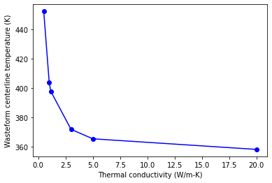

```python
plt.plot(K1, T_centerline, 'bo-')
plt.xlabel('Thermal conductivity (W/m-K)')
plt.ylabel('Wasteform centerline temperature (K)')
plt.show()
```

How is the above graph to be intepreted when analyzing a real waste material, such as tellurite glass?

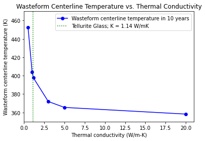

```python
# Tellurite Glass
plt.plot(K1, T_centerline, 'bo-', label='Wasteform centerline temperature in 10 years')
plt.plot([1.14, 1.14], [0, 60000], 'g:', label='Tellurite Glass; K = 1.14 W/mK')
#plt.plot([0, 21], [935.15,935.15], 'r:', label='Tellurite Glass melting point')
plt.xlim([0, 21])
plt.ylim([350, 470])
plt.title('Wasteform Centerline Temperature vs. Thermal Conductivity')
plt.xlabel('Thermal conductivity (W/m-K)')
plt.ylabel('Wasteform centerline temperature (K)')
plt.legend()
plt.show()
```

The following waste materials were studied in depth and their melting points and thermal conductivities are listed below. These thermal conductivities will be used to calculate the centerline temperature at different times in the waste material. Three graphs will be plotted showing how the centerline temperatures change over time. Different wasteforms will be plotted on the same graph so that differences in their trends will be easily identifiable.

Important Note: The following graphs will only show the curves corresponding to sodalite and aluminosilicate waste forms as these waste materials had the highest and lowest thermal conductivities respectively out of the waste materials analyzed in this study. All of the curves for the other waste materials will fall in between these values. This was done to make the graph easier to intepret.

```python
# Tellurite Glass
K1_wf1 = 1.14  # W/mK # @293K
t1_melt = 935.15  # K
```

```python
#Fluorapatite
K1_wf2 = 2.0 # W/mK # @293K
t2_melt = 1660.0 # K
```

```python
#Chlorapatite
K1_wf3 = 2.0 # W/mK # @293K
t3_melt = 1530.0 # K
```

```python
#Sodalite
K1_wf4 = 3.53 # W/mk # @300K
t4_melt = 1352.15 # K
```

```python
#Aluminosilicate
K1_wf5 = .96 # W/mK # @293K
t5_melt = 1683 # K
```

```python
#Titanate
K1_wf6 = 2.7 # W/mK # @293K
t6_melt = 1670.15 # K
```

```python
#Borosilicate Glass
K1_wf7 = 1.2 # W/mK # @363K
t7_melt = 1921 # K
```

```python
#Sodalite has the highest thermal conductivity
#Aluminosilicate has the lowest thermal conductivity
#All of the graph trends for other materials will fall in between these two
```

Each graph will assume a different amount of waste initially; 500 kg, 1000 kg, and 1500 kg

# Assuming 500 kg of waste per canister

```python
T_centerline_wf4 = []
T_centerline_wf5 = []

for i in range(len(Qa)):

    tmp_wf4 = Temperature_middle_final(T0, r2, h0, Qa[i], L, r1, K2, K1_wf4)
    T_centerline_wf4.append(tmp_wf4)
    tmp_wf5 = Temperature_middle_final(T0, r2, h0, Qa[i], L, r1, K2, K1_wf5)
    T_centerline_wf5.append(tmp_wf5)
```

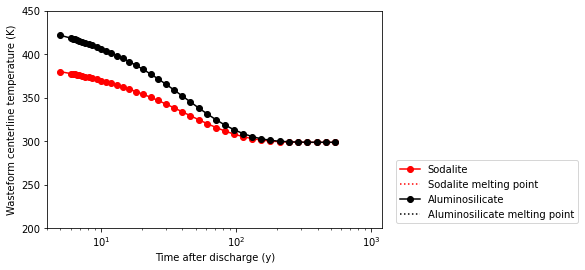

```python
plt.plot(t, T_centerline_wf4, 'ro-', label='Sodalite')
plt.plot([1.0, max(t) * 2], [t4_melt, t4_melt], 'r:', label='Sodalite melting point')
plt.plot(t, T_centerline_wf5, 'ko-', label='Aluminosilicate')
plt.plot([1.0, max(t) * 2], [t5_melt, t5_melt], 'k:', label='Aluminosilicate melting point')

plt.xlim([4, 1.2e3])
plt.ylim([200,450])
plt.xlabel('Time after discharge (y)')
plt.ylabel('Wasteform centerline temperature (K)')
plt.xscale('log')
plt.legend(loc='lower right', bbox_to_anchor=(1.6, 0.0))
plt.show()
```

# Assuming 1000 kg of waste per canister

```python
T_centerline_wf4 = []
T_centerline_wf5 = []

for i in range(len(Qb)):

    tmp_wf4 = Temperature_middle_final(T0, r2, h0, Qb[i], L, r1, K2, K1_wf4)
    T_centerline_wf4.append(tmp_wf4)
    tmp_wf5 = Temperature_middle_final(T0, r2, h0, Qb[i], L, r1, K2, K1_wf5)
    T_centerline_wf5.append(tmp_wf5)
```

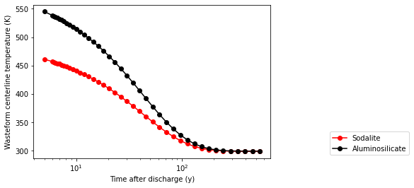

```python
plt.plot(t, T_centerline_wf4, 'ro-', label='Sodalite')
#plt.plot([1.0, max(t) * 2], [t4_melt, t4_melt], 'r:', label='Sodalite melting point')
plt.plot(t, T_centerline_wf5, 'ko-', label='Aluminosilicate')
#plt.plot([1.0, max(t) * 2], [t5_melt, t5_melt], 'k:', label='Aluminosilicate melting point')


#plt.xlim([4, 1.2e3])
#plt.ylim([350,550])
plt.xlabel('Time after discharge (y)')
plt.ylabel('Wasteform centerline temperature (K)')
plt.xscale('log')
plt.legend(loc='lower right', bbox_to_anchor=(1.6, 0.0))
plt.show()
```

# Assuming 1500 kg of waste per canister

```python
T_centerline_wf4 = []
T_centerline_wf5 = []

for i in range(len(Qc)):

    tmp_wf4 = Temperature_middle_final(T0, r2, h0, Qc[i], L, r1, K2, K1_wf4)
    T_centerline_wf4.append(tmp_wf4)
    tmp_wf5 = Temperature_middle_final(T0, r2, h0, Qc[i], L, r1, K2, K1_wf5)
    T_centerline_wf5.append(tmp_wf5)
```

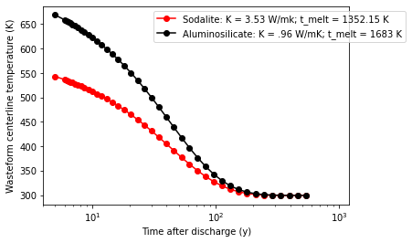

```python
plt.plot(t, T_centerline_wf4, 'ro-', label='Sodalite: K = 3.53 W/mk; t_melt = 1352.15 K')

plt.plot(t, T_centerline_wf5, 'ko-', label='Aluminosilicate: K = .96 W/mK; t_melt = 1683 K')


plt.xlim([4, 1.2e3])
#plt.ylim([700,1200])

plt.xlabel('Time after discharge (y)')
plt.ylabel('Wasteform centerline temperature (K)')
plt.xscale('log')
plt.legend(loc='upper right', bbox_to_anchor=(1.2, 1))
plt.show()
```

```python
T_centerline_wf4_500 = []
T_centerline_wf4_1000 = []
T_centerline_wf4_1500 = []

for i in range(len(Qa)):

    tmp_wf4_500 = Temperature_middle_final(T0, r2, h0, Qa[i], L, r1, K2, K1_wf4)
    T_centerline_wf4_500.append(tmp_wf4_500)

for i in range(len(Qb)):

    tmp_wf4_1000 = Temperature_middle_final(T0, r2, h0, Qb[i], L, r1, K2, K1_wf4)
    T_centerline_wf4_1000.append(tmp_wf4_1000)

for i in range(len(Qc)):

    tmp_wf4_1500 = Temperature_middle_final(T0, r2, h0, Qc[i], L, r1, K2, K1_wf4)
    T_centerline_wf4_1500.append(tmp_wf4_1500)
```

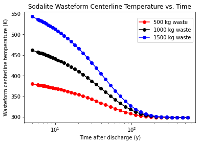

```python
plt.plot(t, T_centerline_wf4_500, 'ro-', label='500 kg waste')
#plt.plot([1.0, max(t) * 2], [t4_melt, t4_melt], 'r:', label='Sodalite melting point')
plt.plot(t, T_centerline_wf4_1000, 'ko-', label='1000 kg waste')


plt.plot(t, T_centerline_wf4_1500, 'bo-', label='1500 kg waste')



#plt.xlim([4, 1.2e3])
#plt.ylim([700,1200])
plt.title('Sodalite Wasteform Centerline Temperature vs. Time')
plt.xlabel('Time after discharge (y)')
plt.ylabel('Wasteform centerline temperature (K)')
plt.xscale('log')
plt.legend(loc='lower right', bbox_to_anchor=(1, .7))
plt.show()
```

### Heat generation vs Time

What is the trend for heat generation as time passes? The following graphs will analyze heat generation over the course of 500+ years

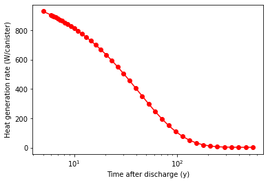

```python
# Plot of decay heat as a function of time assuming 500 kg of waste per canister
plt.plot(t, Qa, 'ro-', label='decay heat as a function of time assuming 500 kg of waste per canister')
plt.xlabel('Time after discharge (y)')
plt.ylabel('Heat generation rate (W/canister)')
plt.xscale('log')
plt.show()
```

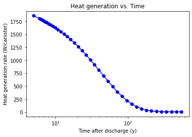

```python
# Plot of decay heat as a function of time assuming 1000 kg of waste per canister
plt.plot(t, Qb, 'bo-', label='Wasteform heat generation rate')
plt.title('Heat generation vs. Time')
plt.xlabel('Time after discharge (y)')
plt.ylabel('Heat generation rate (W/canister)')
plt.xscale('log')
plt.show()
```

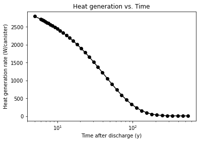

```python
# Plot of decay heat as a function of time assuming 1500 kg of waste per canister
plt.plot(t, Qc, 'ko-', label='Wasteform heat generation rate')
plt.title('Heat generation vs. Time')
plt.xlabel('Time after discharge (y)')
plt.ylabel('Heat generation rate (W/canister)')
plt.xscale('log')
plt.show()
```

# Canister Dimension Affect

How does the canister size affect the dissipation of heat throughout the system? Three canisters with varying radii will be analyzed. 'Canister dimension values obtained from Milos Atz's dissertation 2019' r1 is the radius to the inner surface of the canister r2 is the radius to the outer surface of the canister Canister thickness = .075 m

```python
# Canister A:

r1A = .285
r2A = .36
```

```python
# Canister B:

r1B = .52
r2B = .595
```

```python
# Canister C:

r1C = .675
r2C = .75
```

```python
# Thermal conductivity constant of sodalite will be used as a reference
K1 = 3.53 # W/mk # @300K
```

```python
# Time values from Fuel Cycle Evaluation and Screening Study
t = [5, 6, 6.175, 6.38, 6.622, 6.906, 7.239, 7.63, 8.091, 8.631, 9.266, 10.012, 10.889, 11.919, 13.129,
         14.551, 16.22, 18.18, 20.49, 23.2, 26.38, 30.12, 34.51, 39.68, 45.74, 52.87, 61.24, 71.07, 82.63,
         96.21, 112.2, 130.9, 152.9, 178.8, 209.2, 244.9, 286.9, 336.2, 394.1, 462.1, 542.1]
```

```python
# Canister length will remain constant
L = 1.34 # m
```

```python
# These values were obtained from “Linear Programming Approach... Ahn&Cheon 2006”
# They will be used as reference values to make proper conversions
r1 = 0.22  # m
r2 = 0.23   # m
```

As the canister size increases, the amount of waste in the canister must also increase because this study assumes that the canister is full at all times. To make sure this is the case, we must use the following equation and apply it for each canister size:

(Initial given heat values) (W) x (Volume of Canister A, B, or C) (M^3) / (Volume of reference canister) (M^3) = (Heat generated by Canister A, B, or C) (W)

-The initial values have been used throughout this study and will be denoted by Qb. -Canisters A, B, and C are the different canister sizes being analyzed in this study -The reference canister refers to the canister dimensions that have been used throughtout this study.

This equation will take the amount of heat generarted by the waste in the reference canister, and convert it to the amount of heat generated by the waste in each different canister (A, B, and C), assuming the canisters are full.

```python
#Qb will be used as a reference for heat values at corresponding time values
print(Qb)

#The values for Qb were obtained and explained in previous calculations: See above
```

[output not shown]

```python
# Volume of initial canister size used in previous analyses
V_0 = (math.pi)*(.22**2)*(1.34)
```

```python
# Volume of canister A
V_A = (math.pi)*(.285**2)*(1.34)
```

```python
# Volume of canister B
V_B = (math.pi)*(.52**2)*(1.34)
```

```python
# Volume of canister C
V_C = (math.pi)*(.675**2)*(1.34)
```

```python
# Initial heat values divided by the initial canister volume (V_0). We will call these values Qb_0
# These values will be converted into the values we are looking for for each canister size
# W/m^3
Qb_0 = [q / V_0 for q in Qb]
```

```python
print(Qb_0)
```

[output not shown]

```python
# Multiplying Qb_0 by the volume of canister A will give us the heat generation of canister A in Watts
Qb_A = [q * V_A for q in Qb_0]
```

```python
print(Qb_A)
```

[output not shown]

```python
# Multiplying Qb_0 by the volume of canister B will give us the heat generation of canister B in Watts
Qb_B = [q * V_B for q in Qb_0]
```

```python
print(Qb_B)
```

[output not shown]

```python
# Multiplying Qb_0 by the volume of canister C will give us the heat generation of canister C in Watts
Qb_C = [q * V_C for q in Qb_0]
```

```python
print(Qb_C)
```

[output not shown]

```python
T_centerline_canister_A = []
T_centerline_canister_B = []
T_centerline_canister_C = []

for i in range(len(Qb_A)):
    tmp_C_A = Temperature_middle_final(T0, r2A, h0, Qb_A[i], L, r1A, K2, K1)
    T_centerline_canister_A.append(tmp_C_A)
for i in range(len(Qb_B)):
    tmp_C_B = Temperature_middle_final(T0, r2B, h0, Qb_B[i], L, r1B, K2, K1)
    T_centerline_canister_B.append(tmp_C_B)
for i in range(len(Qb_C)):
    tmp_C_C = Temperature_middle_final(T0, r2C, h0, Qb_C[i], L, r1C, K2, K1)
    T_centerline_canister_C.append(tmp_C_C)
```

```python
print(T_centerline_canister_A)
```

[output not shown]

```python
print(T_centerline_canister_B)
```

[output not shown]

```python
print(T_centerline_canister_C)
```

[output not shown]

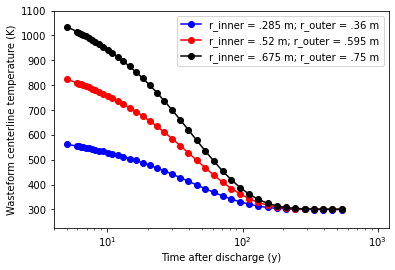

```python
plt.plot(t, T_centerline_canister_A, 'bo-', label='r_inner = .285 m; r_outer = .36 m')

plt.plot(t, T_centerline_canister_B, 'ro-', label='r_inner = .52 m; r_outer = .595 m')

plt.plot(t, T_centerline_canister_C, 'ko-', label='r_inner = .675 m; r_outer = .75 m')


plt.xlim([4, 1.2e3])
plt.ylim([225,1100])
plt.xlabel('Time after discharge (y)')
plt.ylabel('Wasteform centerline temperature (K)')
plt.xscale('log')
plt.legend(loc='upper right')
plt.show()
```

[output not shown]

[figure not shown]

```python
plt.legend(loc='lower right', bbox_to_anchor=(1.6, 0.0))
```

# Junk Stuff!

```python
plt.plot(t, T_centerline_wf1, 'bo-', label='Tellurite Glass')
plt.plot([1.0, max(t) * 2], [t1_melt, t1_melt], 'b:', label='Tellurite Glass melting point')
plt.plot(t, T_centerline_wf2, 'ro-', label='Fluorapatite')
plt.plot([1.0, max(t) * 2], [t2_melt, t2_melt], 'r:', label='Fluorapatite melting point')
plt.plot(t, T_centerline_wf3, 'go-', label='Chlorapatite')
plt.plot([1.0, max(t) * 2], [t3_melt, t3_melt], 'g:', label='Chlorapatite melting point')
plt.plot(t, T_centerline_wf4, 'yo-', label='Sodalite')
plt.plot([1.0, max(t) * 2], [t4_melt, t4_melt], 'y:', label='Sodalite melting point')
plt.plot(t, T_centerline_wf5, 'co-', label='Aluminosilicate')
plt.plot([1.0, max(t) * 2], [t5_melt, t5_melt], 'c:', label='Aluminosilicate melting point')
plt.plot(t, T_centerline_wf6, 'mo-', label='Titanate')
plt.plot([1.0, max(t) * 2], [t6_melt, t6_melt], 'm:', label='Titanate melting point')
plt.plot(t, T_centerline_wf7, 'wo-', label='Borosilicate Glass')
plt.plot([1.0, max(t) * 2], [t7_melt, t7_melt], 'w:', label='Borosilicate Glass melting point')

plt.xlim([4, 1.2e3])
plt.ylim([700,1200])
plt.xlabel('Time after discharge (y)')
plt.ylabel('Wasteform centerline temperature (K)')
plt.xscale('log')
plt.legend(loc='lower right', bbox_to_anchor=(1.6, 0.0))
plt.show()
```

[output not shown]

```python
T_centerline_wf1 = []
T_centerline_wf2 = []
T_centerline_wf3 = []
T_centerline_wf4 = []
T_centerline_wf5 = []
T_centerline_wf6 = []
T_centerline_wf7 = []
for i in range(len(Qa)):
    tmp_wf1 = Temperature_middle_final(T0, r2, h0, Qa[i], L, r1, K2, K1_wf1)
    T_centerline_wf1.append(tmp_wf1)
    tmp_wf2 = Temperature_middle_final(T0, r2, h0, Qa[i], L, r1, K2, K1_wf2)
    T_centerline_wf2.append(tmp_wf2)
    tmp_wf3 = Temperature_middle_final(T0, r2, h0, Qa[i], L, r1, K2, K1_wf3)
    T_centerline_wf3.append(tmp_wf3)
    tmp_wf4 = Temperature_middle_final(T0, r2, h0, Qa[i], L, r1, K2, K1_wf4)
    T_centerline_wf4.append(tmp_wf4)
    tmp_wf5 = Temperature_middle_final(T0, r2, h0, Qa[i], L, r1, K2, K1_wf5)
    T_centerline_wf5.append(tmp_wf5)
    tmp_wf6 = Temperature_middle_final(T0, r2, h0, Qa[i], L, r1, K2, K1_wf6)
    T_centerline_wf6.append(tmp_wf6)
    tmp_wf7 = Temperature_middle_final(T0, r2, h0, Qa[i], L, r1, K2, K1_wf7)
    T_centerline_wf7.append(tmp_wf7)
```

```python
plt.plot(t, T_centerline_wf1, 'bo-', label='Tellurite Glass')
plt.plot([1.0, max(t) * 2], [t1_melt, t1_melt], 'b:', label='Tellurite Glass melting point')
plt.plot(t, T_centerline_wf2, 'ro-', label='Fluorapatite')
plt.plot([1.0, max(t) * 2], [t2_melt, t2_melt], 'r:', label='Fluorapatite melting point')
plt.plot(t, T_centerline_wf3, 'go-', label='Chlorapatite')
plt.plot([1.0, max(t) * 2], [t3_melt, t3_melt], 'g:', label='Chlorapatite melting point')
plt.plot(t, T_centerline_wf4, 'yo-', label='Sodalite')
plt.plot([1.0, max(t) * 2], [t4_melt, t4_melt], 'y:', label='Sodalite melting point')
plt.plot(t, T_centerline_wf5, 'co-', label='Aluminosilicate')
plt.plot([1.0, max(t) * 2], [t5_melt, t5_melt], 'c:', label='Aluminosilicate melting point')
plt.plot(t, T_centerline_wf6, 'mo-', label='Titanate')
plt.plot([1.0, max(t) * 2], [t6_melt, t6_melt], 'm:', label='Titanate melting point')
plt.plot(t, T_centerline_wf7, 'wo-', label='Borosilicate Glass')
plt.plot([1.0, max(t) * 2], [t7_melt, t7_melt], 'w:', label='Borosilicate Glass melting point')

plt.xlim([4, 1.2e3])
plt.ylim([600,1000])
plt.xlabel('Time after discharge (y)')
plt.ylabel('Wasteform centerline temperature (K)')
plt.xscale('log')
plt.legend(loc='lower right', bbox_to_anchor=(1.6, 0.0))
plt.show()
```

[output not shown]

```python
T_centerline_wf1 = []
T_centerline_wf2 = []
T_centerline_wf3 = []
T_centerline_wf4 = []
T_centerline_wf5 = []
T_centerline_wf6 = []
T_centerline_wf7 = []
for i in range(len(Qb)):
    tmp_wf1 = Temperature_middle_final(T0, r2, h0, Qb[i], L, r1, K2, K1_wf1)
    T_centerline_wf1.append(tmp_wf1)
    tmp_wf2 = Temperature_middle_final(T0, r2, h0, Qb[i], L, r1, K2, K1_wf2)
    T_centerline_wf2.append(tmp_wf2)
    tmp_wf3 = Temperature_middle_final(T0, r2, h0, Qb[i], L, r1, K2, K1_wf3)
    T_centerline_wf3.append(tmp_wf3)
    tmp_wf4 = Temperature_middle_final(T0, r2, h0, Qb[i], L, r1, K2, K1_wf4)
    T_centerline_wf4.append(tmp_wf4)
    tmp_wf5 = Temperature_middle_final(T0, r2, h0, Qb[i], L, r1, K2, K1_wf5)
    T_centerline_wf5.append(tmp_wf5)
    tmp_wf6 = Temperature_middle_final(T0, r2, h0, Qb[i], L, r1, K2, K1_wf6)
    T_centerline_wf6.append(tmp_wf6)
    tmp_wf7 = Temperature_middle_final(T0, r2, h0, Qb[i], L, r1, K2, K1_wf7)
    T_centerline_wf7.append(tmp_wf7)
```

[figure not shown]

```python
plt.plot(t, T_centerline_wf1, 'bo-', label='Tellurite Glass')
plt.plot([1.0, max(t) * 2], [t1_melt, t1_melt], 'b:', label='Tellurite Glass melting point')
plt.plot(t, T_centerline_wf2, 'ro-', label='Fluorapatite')
plt.plot([1.0, max(t) * 2], [t2_melt, t2_melt], 'r:', label='Fluorapatite melting point')
plt.plot(t, T_centerline_wf3, 'go-', label='Chlorapatite')
plt.plot([1.0, max(t) * 2], [t3_melt, t3_melt], 'g:', label='Chlorapatite melting point')
plt.plot(t, T_centerline_wf4, 'yo-', label='Sodalite')
plt.plot([1.0, max(t) * 2], [t4_melt, t4_melt], 'y:', label='Sodalite melting point')
plt.plot(t, T_centerline_wf5, 'co-', label='Aluminosilicate')
plt.plot([1.0, max(t) * 2], [t5_melt, t5_melt], 'c:', label='Aluminosilicate melting point')
plt.plot(t, T_centerline_wf6, 'mo-', label='Titanate')
plt.plot([1.0, max(t) * 2], [t6_melt, t6_melt], 'm:', label='Titanate melting point')
plt.plot(t, T_centerline_wf7, 'wo-', label='Borosilicate Glass')
plt.plot([1.0, max(t) * 2], [t7_melt, t7_melt], 'w:', label='Borosilicate Glass melting point')

plt.xlim([4, 1.2e3])
plt.ylim([700,1100])
plt.xlabel('Time after discharge (y)')
plt.ylabel('Wasteform centerline temperature (K)')
plt.xscale('log')
plt.legend(loc='lower right', bbox_to_anchor=(1.6, 0.0))
plt.show()
```

```python
T_centerline_wf1 = []
T_centerline_wf2 = []
T_centerline_wf3 = []
T_centerline_wf4 = []
T_centerline_wf5 = []
T_centerline_wf6 = []
T_centerline_wf7 = []
for i in range(len(Qc)):
    tmp_wf1 = Temperature_middle_final(T0, r2, h0, Qc[i], L, r1, K2, K1_wf1)
    T_centerline_wf1.append(tmp_wf1)
    tmp_wf2 = Temperature_middle_final(T0, r2, h0, Qc[i], L, r1, K2, K1_wf2)
    T_centerline_wf2.append(tmp_wf2)
    tmp_wf3 = Temperature_middle_final(T0, r2, h0, Qc[i], L, r1, K2, K1_wf3)
    T_centerline_wf3.append(tmp_wf3)
    tmp_wf4 = Temperature_middle_final(T0, r2, h0, Qc[i], L, r1, K2, K1_wf4)
    T_centerline_wf4.append(tmp_wf4)
    tmp_wf5 = Temperature_middle_final(T0, r2, h0, Qc[i], L, r1, K2, K1_wf5)
    T_centerline_wf5.append(tmp_wf5)
    tmp_wf6 = Temperature_middle_final(T0, r2, h0, Qc[i], L, r1, K2, K1_wf6)
    T_centerline_wf6.append(tmp_wf6)
    tmp_wf7 = Temperature_middle_final(T0, r2, h0, Qc[i], L, r1, K2, K1_wf7)
    T_centerline_wf7.append(tmp_wf7)
```

# Parametric Equations

There are lots of unknowns for molten salt reactor waste management. The fuel salt is molten in the reactor and salts are soluble in water, so spent fuel salt will need to be immobilized prior to disposal. However, no one has made any decisions about:

1. The material in which waste salt will be immobilized;
2. The relative amounts of waste and immobilizer in the mixture (e.g. 30% waste salt, 70% immobilizing matrix)
3. The properties of the waste form (thermal conductivity, melting point)
4. The time between spent salt discharge from the reactor and its immobilization in a disposable waste form.

As such, our study seeks to explore the impact of some of these parameters as they relate to the waste form peak temperature, which must be kept below a certain limit in order to prevent melting. Our main parameters of interest are:

- The thermal conductivity of the waste form
- The peak temperature limit we apply to prevent melting
- The heat generation rate (W) in the waste form.

Note that heat generation rate is a function of (1) time between spent fuel salt discharge and immobilization: because of radioactive decay, the waste heat generation decreases exponentially over time. Technically, all of the above parameters are also a function of waste form loading, meaning the relative amounts of waste and immobilizing matrix in the waste form mixture. A waste form with 50% salt, 50% matrix will have higher heat per volume and a different thermal conductivity than a waste form with 25% salt, 75% matrix. The waste form loading depends on the matrix.

In the following cells, I've set up some calculations for you to perform. You'll need to fill in values with data (decay heat, thermal conductivity, etc), run the calculations, and plot the results. Then, we'll talk about what they mean!

But first, a quick note about decay heat and waste loading The decay heat values I gave you are in W but are for the total mass of waste fuel salt discharged from a reactor generating 100 GWe-y of electricity (GWe-y is "gigawatt-electric-years"); in reality, that's "W/100GWe-y", which is not all that helpful for us. What we really need for our calculations is W/canister. To get that, we need to know (a) how much waste salt was generated to product 100 GWe-y and (b) how much waste salt goes into each canister.

The answer to part (a) is easy: 724.4 t of discharged spent fuel, not including the salt carrier (per Appendix B of the "Fuel Cycle Evaluation and Screening Study"). With that, we can do q_original (W/100GWe-y) *100 GWe-y / 724.4 t* 1 t / 1000 kg = q_per_unit_mass (W/kg). Note that this is kg spent fuel materials (fuel, fission and decay products) and ignores any carrier salt also discharged. We can ignore the salt carrier - let's assume it's distilled away prior to waste form preparation.

Now, we need to know how much waste salt is put into a single waste canister. This is a tricky question. First, recall that the waste salts need to be mixed with immobilizing matrix. How much is appropriate to mix? 10%? 25%? 50%? Second, what's the density of that mixture? We've got a canister volume to fill. These things are not known to us. Let's skip all of this by making an assumption - let's assume 500 kg of waste will go into a canister. That was approximately the optimum result from the case study in Ahn's 2006 linear programming paper. The rest of the space in the canister will be immobilization matrix. We don't know what that means for waste loading, but this drastically simplifies our work.

Evaluating this for every time point in the data will give us a canister decay heat curve.